# SDM_Method_Oxycarenus_hyalinipennis

Travis Rhodes

6/22/2022

## Front Matter

The following script was developed cooperatively by the SHSU SDM working group, including Laura Bianchi, Austin Brenek, Jesus Castillo, Nick Galle, Kayla Hankins, Kenneth Nobleza, Chris Randle, Nico Reger, Alyssa Russell, Ava Stendahl based on [tutorials](https://rspatial.org/) provided by Robert Hijmans and Jane Elith. Chris Randle composed the following script from many scripts developed by the SHSU SDM working group.

*This works best if your environment is empty at the start.*

I have tried to set this up to eliminate required changes to the code. When you see text in **BOLD** below, that will be an indication that you need to make a decision.

# Libraries

```r
library(dismo)
library(sp)
library(raster)
library(stats)
library(dplyr)
library(knitr)
library(rgeos)
```

```r
library(maptools)
library(rgdal)
library(ecospat)
library(usdm)
library(mgcv)
```

# Genus and Species strings

Their are many places in this code where you will need to save files with filenames including the genus and species. We’ll save these as strings to automate the creation of file names. Enter your genus name and specific epithet in the quotes below.

```r
genus<-"Oxycarenus"
species<-"hyalinipennis"
```

## Occurrence Data

Import occurrence data from csv file already generated (2020-2021), or using the script “Occurrence_Data.rmd” and visualize it. USING DATA FROM HOME RANGE OF EU, N AFRICA, LEVANT

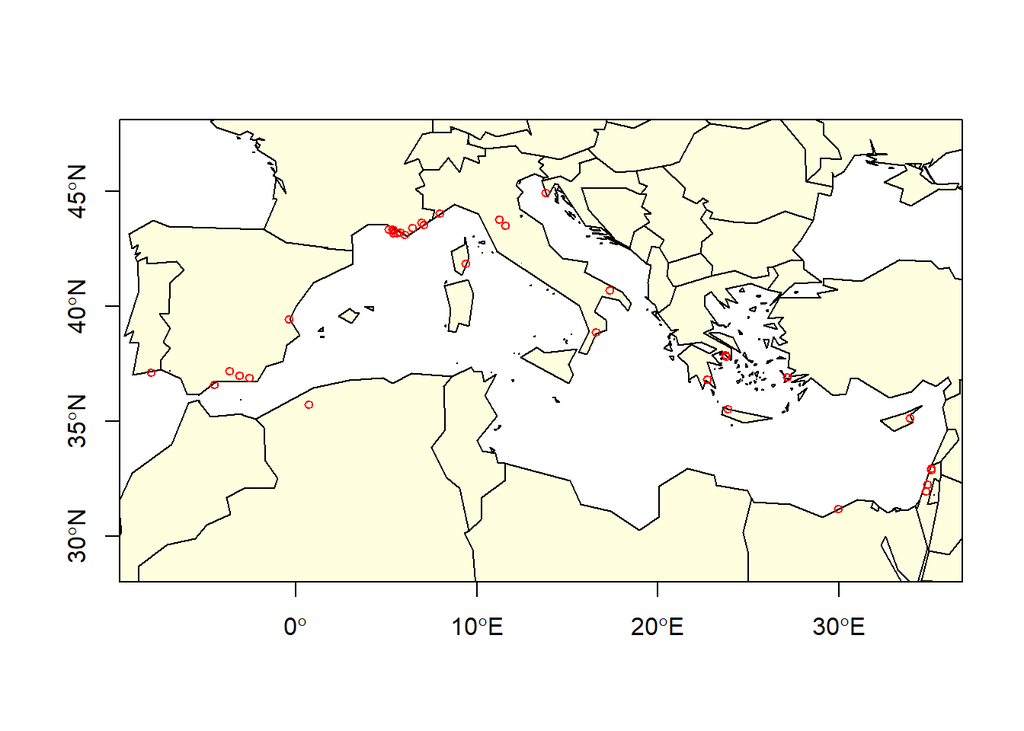

```r
sdmdata<-read.csv(file=paste0("Oxycarenus_hyalinipennis_clean.csv"))
##and visualize the data
#first lets get the extent of the data (the coordinates of the smallest box needed to encapsulate the data)  To do this I first need to convert sdmdata into a spatial points dataframe with the same crs as "wrldsmpl", a giant spatial polygons data frame available from maptools
sdmdataframe<-data.frame(sdmdata)
data(wrld_simpl)
coordinates(sdmdataframe) <- ~lon+lat
crs(sdmdataframe) <- crs(wrld_simpl)
#And then extract the extent
e<-extent(sdmdataframe)
xmin<-xmin(e)
xmax<-xmax(e)
ymin<-ymin(e)
ymax<-ymax(e)
# and then plot a map and add the points from sdmdata
plot(wrld_simpl, xlim=c(xmin,xmax), ylim=c(ymin,ymax), axes=TRUE, col="light yellow")
box()
points(sdmdata$lon, sdmdata$lat, col='red', cex=0.75)
```

Let’s divide the data into training and testing data sets. The following code divides the data set into 80% training and 20% testing.

```r
#let's make sdmdata into a dataframe
data(wrld_simpl)
coordinates(sdmdata) <- ~lon+lat
crs(sdmdata) <- crs(wrld_simpl)

#let's extract just the coordinates
presence <- coordinates(sdmdata)
#First we'll make a random list of integers from 1-5 as long as our presence data. Setting the seed results in a repeatable random process
set.seed(0)
#now make a list as long as the number of rows in presence consisting of a random series of integers from 1-5
group <- kfold(presence, 5)
#Then we want to use this to retrieve the number of the rows in the presence data that are associated with the number 1 in our group index.
test_indices <- as.integer(row.names(presence[group == 1, ]))
#and create a new list of coordinates including only those rows that are NOT in test indices. These are all the row numbers NOT corresponding with the test_indices (which is ~80% of the data).
pres_train <- presence[-test_indices,]
#and those that do correspond with test indices (20%) of the data
pres_test <- presence[group ==1,]
```

Save pres_data and test_data as csv files just in case.

```r
#first presdata_train
outdata<-data.frame(pres_train)
colnames(outdata)<-c("lon","lat")
write.csv(outdata, file=paste0(genus,"_",species,"_train.csv"), row.names=FALSE)

#and then presdata_test
outdata<-data.frame(pres_test)
colnames(outdata)<-c("lon","lat")
write.csv(outdata, file=paste0(genus,"_",species,"_test.csv"), row.names=FALSE)
```

## Predictor data

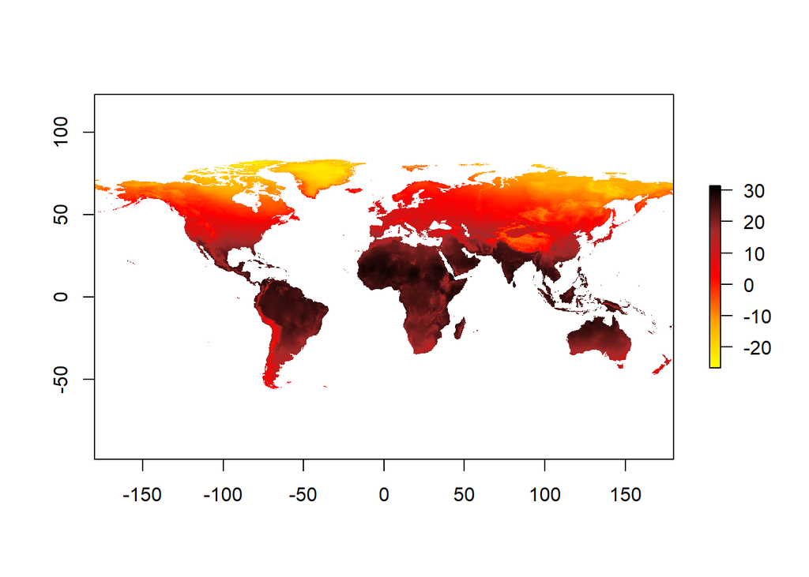

```r
predictors<-stack('Climond_elev_HI.tif')
bands<-c("Ann_mean_temp",   "Mean_durnal_temp_range",   "Isothermality",    "Temp_Seasonality", "MaxTemp_WarmestWeek",  "MinTemp_ColdestWeek",  "Temp_Annual_Range",    "Mean_temp_wettest_q",  "Mean_temp_driest_q",   "Mean_temp_warmiest_q", "Mean_temp_coldest_q",  "Ann_ precip",  "Precip_driest_week",   "Precip_wettest_week",  "Precip_Seasonality",   "Precip_wettest_q", "Precip_driest_q",  "Precip_warmest_q", "Precip_coldest_q", "Ann_mean_rad", "Hghest_weekly_rad",    "Lowest_weekly_rad",    "Rad_seasonality",  "Rad_wettest_q",    "Rad_driest_q", "Rad_warmest_q",    "Rad_coldest_q",    "Ann_mean_moisture",    "Highsets_weekly_moisture", "Lowest_weekly_moisture",   "Moisture_seasonality", "Mean_moisture_wettest_q",  "Mean_moisture_driest_q",   "Mean_moisture_warmest_q",  "Mean_moisture_coldest_q",  "Elev", 'human_impact')
names(predictors)<-bands
cool<-colorRampPalette(c('gray','green','dark green',"blue"))
warm<-colorRampPalette(c('yellow', 'orange', 'red', 'brown', 'black'))
plot(predictors[["Ann_mean_temp"]], col=warm(100))
```

And now we will use the VIFstep function to identify layers contributing most to collinearity (variance inflation factor). Rather than do this from a raster, I think it makes much more sense to do this from a dataframe in which we have sampled all the layers at the presence points only. This is because the larger a species distribution is, the lower the probability of collinearity across the range, even if layers are collinier where the species actually exists in the range.

```r
#extract environmental data using the points in sdmdata
env_data<-extract(predictors,sdmdata)
#give names to the columns
colnames(env_data)<-bands
#run the vif
vif<-vifstep(env_data)
```

[output not shown]

[output cut: 574 more lines]

[output not shown]

```r
#and let's find the layers that were excluded and drop them
excluded<-vif@excluded
predictors<-dropLayer(predictors,excluded)
#and let's just go ahead and see which layers were dropped.
NClayers<-names(predictors)
NClayers
```

```
## [1] "Mean_temp_warmiest_q"    "Ann_.precip"
## [3] "Precip_driest_week"      "Precip_wettest_week"
## [5] "Rad_wettest_q"           "Rad_warmest_q"
## [7] "Mean_moisture_coldest_q" "Elev"
## [9] "human_impact"
```

# Data preparation

Generally speaking, we want to sample absence data from the region in which the presence data occur. There are two ways to do that, and one of them is better than the other. The first is to sample randomly. That may seem like a good idea, but its counter-intuitively not. The reason is that the presence data likely includes sampling bias. This will be inherent in p(hypothesis). If we include the same sampling bias in p(data), they cancel out in Bayes Theorem. The way that we’ll do that is to create circles around our data and sample absence points from within those. The circles will have a diameter equal to the average distance between points.

```r
#convert presence training data into a spatial points dataframe.
pres_train_SPDF<-SpatialPoints(pres_train)
crs(pres_train_SPDF) <- crs(wrld_simpl)
#Let's get the average distance between points (great circle distance--takes into account the curvature of the earth). spDists creates a matrix of distances between points. This includes zeros.
dist<-spDists(pres_train_SPDF,longlat = TRUE)
#replace the zeros with NA
dist[dist == 0]<-NA
#and calculate the mean--this is the average distance between points...the result will be in kilometers, but we need to convert it to meters so we multiply by 1000
dist<-1000*mean(dist, na.rm=TRUE)
#now we are going to make circles using the average distance between points as the diameter.
x <- circles(pres_train_SPDF, d=dist, lonlat=TRUE)
#and convert those into polygons
pol <- polygons(x)
#and draw a number of samples from that approximately three times the number of presence points. We'll chop that down at the end.
samp1 <- spsample(pol, nrow(pres_train)*3, type='random', iter=25)
#and get the cell numbers from the raster stack (right to left, up to down)
cells <- cellFromXY(predictors, samp1)
#and transform each of those to the center of its cell.
abs_train <- xyFromCell(predictors, cells)
#You'll get a warning saying that your CRS object has lost a comment. This is unimportant and can be ignored.
```

And let’s go ahead and extract the presence data, remove rows with NA values, and add a column of 1s.

```r
pres_train_data<-extract(predictors,pres_train)
complete<-complete.cases(pres_train_data)
pres_train_data<-pres_train_data[complete,]
pres_train_data<-cbind(pres_train_data,1)
```

Now we want to extract predictors for the absence data, remove rows with NA values and chop it down to the size of our presence training data, and combine these into one data frame with column names (pa is the last column of 0,1 which indicates presence or absence)

```r
abs_train_data<-extract(predictors,abs_train)
#remove rows with NA values
complete<-complete.cases(abs_train_data)
abs_train_data<-abs_train_data[complete,]
#and select a number of rows equal to the presence training data
abs_train_data<-abs_train_data[1:nrow(pres_train_data),]
#and add a column of zeros to the end.
abs_train_data<-cbind(abs_train_data,0)
#put the two matrices together and name the colmns
train_data<-rbind(pres_train_data,abs_train_data)
colnames(train_data)<-c(names(predictors),"pa")
train_data<-as.data.frame(train_data)
```

# Training the GAM and making predictions.

**This is a pain in the neck because all of the layers have to be specified. I recommend printing the column names in the console `colnames(train_data)` and then copying them and formatting them**

```r
gam <- gam(pa ~  Mean_temp_warmiest_q+ Ann_.precip + Precip_driest_week + Precip_wettest_week + Rad_wettest_q + Rad_warmest_q + Mean_moisture_coldest_q + Elev + human_impact,
           family = binomial(link = "logit"), data=train_data)
summary(gam)
```

```
##
## Family: binomial
## Link function: logit
##
## Formula:
## pa ~ Mean_temp_warmiest_q + Ann_.precip + Precip_driest_week +
##     Precip_wettest_week + Rad_wettest_q + Rad_warmest_q + Mean_moisture_coldest_q +
##     Elev + human_impact
##
## Parametric coefficients:
##                           Estimate Std. Error z value Pr(>|z|)
## (Intercept)              5.0847520 23.5164353   0.216    0.829
## Mean_temp_warmiest_q    -0.4566556  0.5441689  -0.839    0.401
## Ann_.precip              0.0165769  0.0169166   0.980    0.327
## Precip_driest_week      -0.0835565  0.3709934  -0.225    0.822
## Precip_wettest_week     -0.7458707  0.4837636  -1.542    0.123
## Rad_wettest_q           -0.0475126  0.0314200  -1.512    0.130
## Rad_warmest_q            0.0194213  0.0496449   0.391    0.696
## Mean_moisture_coldest_q -5.7709256 10.3020363  -0.560    0.575
## Elev                     0.0004225  0.0034669   0.122    0.903
## human_impact             0.2348093  0.1434980   1.636    0.102
##
##
## R-sq.(adj) =  0.814   Deviance explained = 80.4%
## UBRE = -0.37131  Scale est. = 1         n = 56
```

Let’s make some predictions and export them to a file

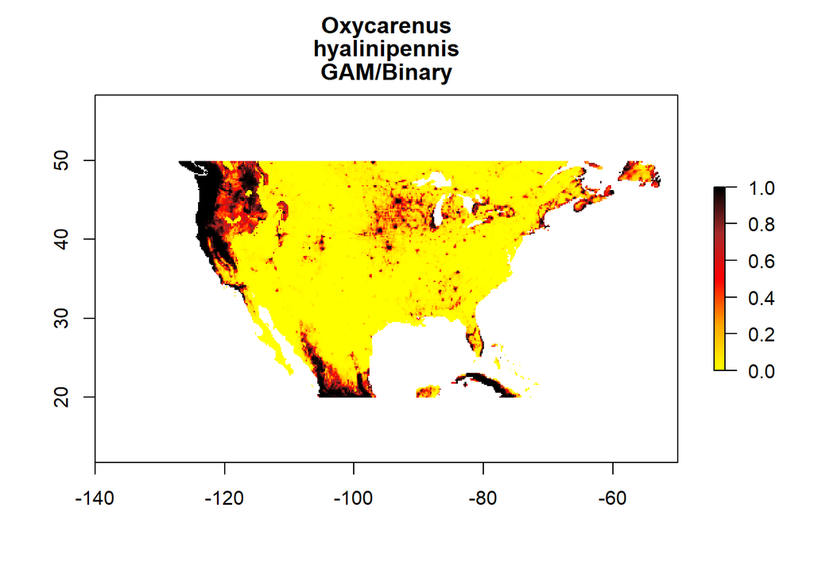

```r
GAMpreds <- predict(predictors, gam, type = 'response')
writeRaster(GAMpreds, filename = paste0(genus,"_",species,"_GAM.tif"), overwrite=TRUE)
plot(GAMpreds, main=c(genus,species,'GAM/Binary'),col=warm(100), zlim=c(0,1), xlim=c(-140, -50), ylim=c(20, 50))
points(pres_test, col='white', cex =.4, pch=3)
```

## MaxEnt

We need many more background points for MaxEnt and BRT than we needed for GAM. Let’s go ahead and generate those.

```r
samp1 <- spsample(pol, 40000, type='random', iter=25)
#and get the cell numbers from the raster stack (right to left, up to down)
cells <- cellFromXY(predictors, samp1)
#and transform each of those to the center of its cell.
background_train <- xyFromCell(predictors, cells)
background_sample<-extract(predictors,background_train)
background_complete<-complete.cases(background_sample)
background_train<-background_train[background_complete,]
background_train<-background_train[1:10000,]
  #You'll get a warning saying that your CRS object has lost a comment. This is unimportant and can be ignored.
```

Let’s go ahead and set a locations for java **This will obviously be specialized for your computer. Try to find the ‘home’ folder in java and specify the path below**

```r
Sys.setenv(JAVA_HOME='C:\\Program Files\\Java\\jdk-11.0.1')
```

First we let the program know to start up maxent using the command maxent. After that, all we need to do is to make a model oject (me_model), from the raster data and the presence training data.

```r
maxent()
```

```
## java.home option:
```

```
## JAVA_HOME environment variable: C:\Program Files\Java\jdk-11.0.1
```

```
## This is MaxEnt version 3.4.3
```

```r
me_model <- maxent(predictors, pres_train, a=background_train)
```

```
## This is MaxEnt version 3.4.3
```

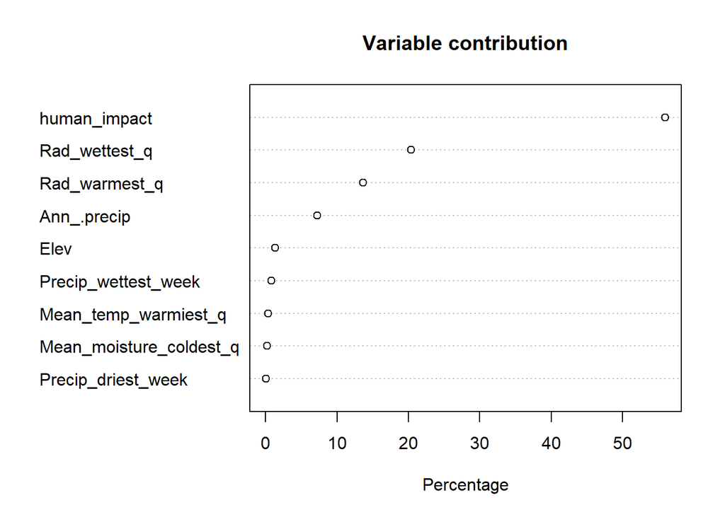

```r
#and plot the models most important layers
par(mfrow=c(1,1))
plot(me_model)
```

MOST IMPORTANT FACTORS ARE HUMAN IMPACT // RAD_WETTEST_Q // RAD_WARMEST_Q // ANN_PRECIP Let’s go ahead and make some predictions

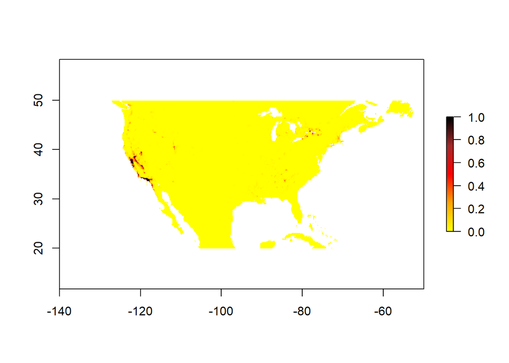

```r
MEpreds<-predict(predictors, me_model, type='response')
writeRaster(MEpreds, filename=paste0(genus,"_",species,"_ME2.tif"),overwrite=TRUE)
#and plot
plot(MEpreds, col=warm(100), zlim=c(0,1), xlim=c(-140, -50), ylim=c(20, 50))
```

## Boosted regression trees

We need to prepare data for BRT in much the same way that we did for GAM, with the exception that we will need a lot more background data. We can use the 10,000 points that we already generated for ME

```r
#let's get the data from our predictors
bg_train_data<-extract(predictors,background_train)
#and bind a column of 0 to the end of it
bg_train_data<-cbind(bg_train_data,0)
#and convert it to a data frame
bg_train_data<-as.data.frame(bg_train_data)
#and then combine it withe the presence training data
pres_train_data<-as.data.frame(pres_train_data)
BRT_data<-rbind(pres_train_data, bg_train_data)
colnames(BRT_data)<-c(names(predictors),"pa")
```

```r
sdm.tc5.lr001 <- gbm.step(data=BRT_data, gbm.x = 1:nlayers(predictors), gbm.y = ncol(BRT_data), family = "bernoulli", tree.complexity = 5, learning.rate = 0.001, bag.fraction = 0.5)
```

```
##
##
##  GBM STEP - version 2.9
##
## Performing cross-validation optimisation of a boosted regression tree model
## for pa and using a family of bernoulli
## Using 10028 observations and 9 predictors
## creating 10 initial models of 50 trees
##
##  folds are stratified by prevalence
## total mean deviance =  0.0384
## tolerance is fixed at  0
## ntrees resid. dev.
## 50    0.0331
## now adding trees...
```

[output cut: 71 more lines]

```
## fitting final gbm model with a fixed number of 3400 trees for pa
```

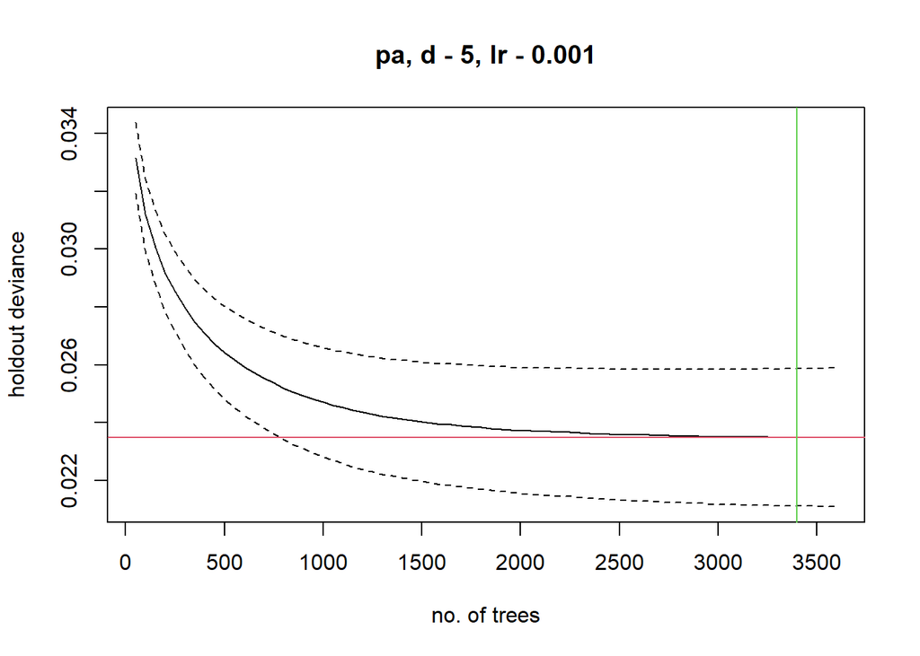

```
##
## mean total deviance = 0.038
## mean residual deviance = 0.01
##
## estimated cv deviance = 0.023 ; se = 0.002
##
## training data correlation = 0.793
## cv correlation =  0.459 ; se = 0.081
##
## training data AUC score = 0.999
## cv AUC score = 0.954 ; se = 0.017
##
## elapsed time -  0.2 minutes
```

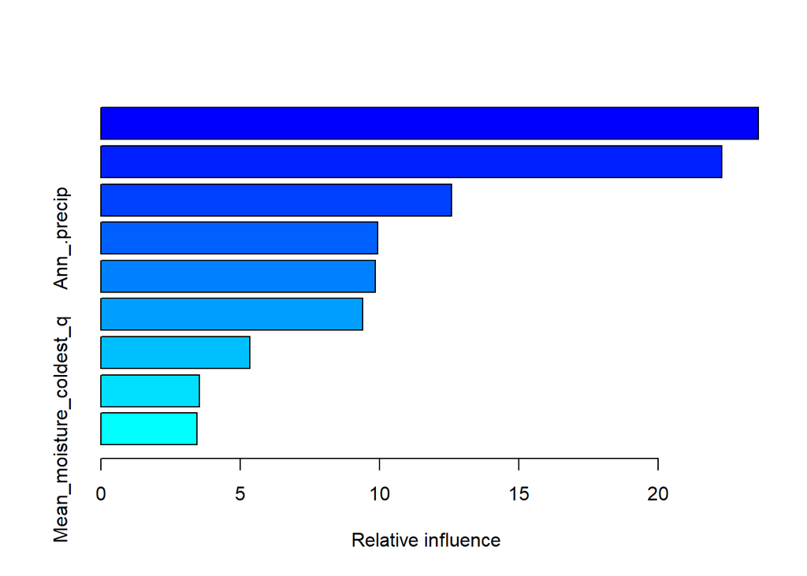

```
##                                             var   rel.inf
## human_impact                       human_impact 23.601154
## Rad_warmest_q                     Rad_warmest_q 22.282352
## Mean_temp_warmiest_q       Mean_temp_warmiest_q 12.585578
## Ann_.precip                         Ann_.precip  9.948469
## Precip_driest_week           Precip_driest_week  9.849976
## Precip_wettest_week         Precip_wettest_week  9.399376
## Rad_wettest_q                     Rad_wettest_q  5.343909
## Elev                                       Elev  3.544237
## Mean_moisture_coldest_q Mean_moisture_coldest_q  3.444949
```

```r
summary(sdm.tc5.lr001)
```

**Note: you may want to try different combinations! If your trees are converging too slowly, raise the tree complexity by 1 or two, and back the learning rate down. On the other hand of your holdout deviance drops very quickly and slowly starts to rise, you are overfitting. Drop the tree complexity and raise the learning rate.**

Let’s make predictions and save them

```r
BRTpreds<-predict(predictors, sdm.tc5.lr001, type='response')
```

```
## Using 3400 trees...
##
## Using 3400 trees...
##
## Using 3400 trees...
##
## Using 3400 trees...
```

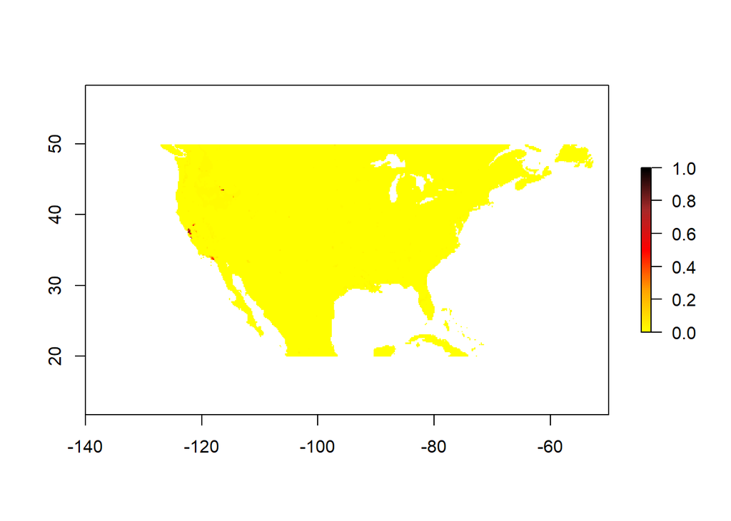

```r
writeRaster(BRTpreds, filename=paste0(genus,"_", species,"_BRT.tif"), overwrite=TRUE)
#and plot
plot(BRTpreds, col=warm(100), zlim=c(0,1), xlim=c(-140, -50), ylim=c(20, 50))
```

## Evaluation

We want to generate the following metrics for each of the three models: AUC, COR, maximum Kappa, TRS, and it wouldn’t kill us to have a Boyce graph either.

```r
pres_test_SPDF<-SpatialPoints(pres_test)
data("wrld_simpl")
crs(pres_test_SPDF) <- crs(wrld_simpl)
#now we are going to make circles of about a degree (110000 meters at the equator). I'm working in a relatively small area, but if your data are widespread, you can increase this by changing d.
x <- circles(pres_test_SPDF, d=dist, lonlat=TRUE)
#and convert those into polygons
pol <- polygons(x)
#and draw a number of samples from that...because
samp1 <- spsample(pol, 4*length(pres_test), type='random', iter=25)
#and get the cell numbers from the raster stack (right to left, up to down)
cells <- cellFromXY(predictors, samp1)
#and transform each of those to the center of its cell.
abs_test <- xyFromCell(predictors, cells)
#You'll get a warning saying that your CRS object has lost a comment. This is unimportant and can be ignored.
```

GAM evaluation

```r
p<-extract(GAMpreds,pres_test)
a<-extract(GAMpreds,abs_test)
#And let's get rid of nasty NA values and shrink a to the size of p
p<-p[!is.na(p)]
a<-a[!is.na(a)]
a<-a[1:length(p)]
#Let's look at the shape of these data
#lets weld all the data together
all_vals<-c(p,a)
e<-evaluate(p=p,a=a)
AUC_GAM<-e@auc
COR_GAM<-e@cor
pa<-c(replicate(length(p),1),replicate(length(a),0))
kappaGAM<-ecospat.max.kappa(all_vals,pa)
TSS_GAM<-ecospat.max.tss(all_vals,pa)
print(paste('Max kappa: ', kappaGAM[2] ))
```

```
## [1] "Max kappa:  0.875"
```

```r
print(paste('TSS:', TSS_GAM[[2]]))
```

```
## [1] "TSS: 0.875"
```

```r
e
```

```
## class          : ModelEvaluation
## n presences    : 8
## n absences     : 8
## AUC            : 0.984375
## cor            : 0.9072346
## max TPR+TNR at : 0.1879812
```

And let’s go ahead and estimate the Boyce Index HAVING A PROBLEM HERE Error in seq.default(from = mini, to = maxi - window.w, by = (maxi - mini - : ‘from’ must be a finite number

```r
#ecospat.boyce(fit=GAMpreds,pres_test,nclass=0,window.w="default",PEplot = TRUE)
```

ME Evaluation

```r
p<-extract(MEpreds,pres_test)
a<-extract(MEpreds,abs_test)
#And let's get rid of nasty NA values and shrink a to the size of p
p<-p[!is.na(p)]
a<-a[!is.na(a)]
a<-a[1:length(p)]
#Let's look at the shape of these data
#lets weld all the data together
all_vals<-c(p,a)
e<-evaluate(p=p,a=a)
AUC_ME<-e@auc
COR_ME<-e@cor
pa<-c(replicate(length(p),1),replicate(length(a),0))
kappaME<-ecospat.max.kappa(all_vals,pa)
TSS_ME<-ecospat.max.tss(all_vals,pa)
print(paste('Max kappa: ', kappaME[2] ))
```

```
## [1] "Max kappa:  1"
```

```r
print(paste('TSS:', TSS_ME[[2]]))
```

```
## [1] "TSS: 1"
```

```r
e
```

```
## class          : ModelEvaluation
## n presences    : 8
## n absences     : 8
## AUC            : 1
## cor            : 0.8780908
## max TPR+TNR at : 0.08343818
```

And let’s go ahead and estimate the Boyce Index HAVING A PROBLEM HERE Error in seq.default(from = mini, to = maxi - window.w, by = (maxi - mini - : ‘from’ must be a finite number

```r
#ecospat.boyce(fit=MEpreds,pres_test,nclass=0,PEplot = TRUE)
```

BRT Evaluation

```r
p<-extract(BRTpreds,pres_test)
a<-extract(BRTpreds,abs_test)
#And let's get rid of nasty NA values and shrink a to the size of p
p<-p[!is.na(p)]
a<-a[!is.na(a)]
a<-a[1:length(p)]
#Let's look at the shape of these data
#lets weld all the data together
all_vals<-c(p,a)
e<-evaluate(p=p,a=a)
AUC_BRT<-e@auc
COR_BRT<-e@cor
pa<-c(replicate(length(p),1),replicate(length(a),0))
kappaBRT<-ecospat.max.kappa(all_vals,pa)
TSS_BRT<-ecospat.max.tss(all_vals,pa)
print(paste('Max kappa: ', kappaBRT[2] ))
```

```
## [1] "Max kappa:  0.75"
```

```r
print(paste('TSS:', TSS_BRT[[2]]))
```

```
## [1] "TSS: 0.75"
```

```r
e
```

```
## class          : ModelEvaluation
## n presences    : 8
## n absences     : 8
## AUC            : 1
## cor            : 0.5829512
## max TPR+TNR at : 0.00240714
```

```r
#ecospat.boyce(fit=BRTpreds,pres_test,nclass=0,PEplot = TRUE)
```

# Making the ensemble and evaluation

The ensemble is simply the average of GAM, ME, and BRT predictions weighted by AUC.

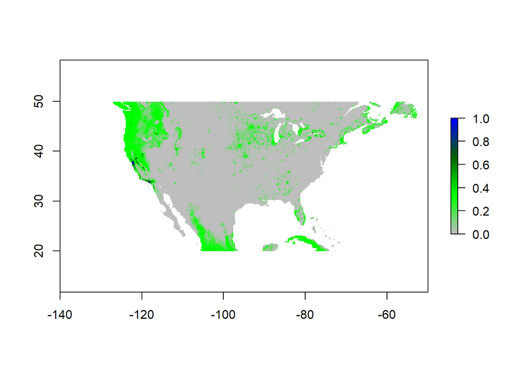

```r
ENSpreds<-(GAMpreds*AUC_GAM+MEpreds*AUC_ME+BRTpreds*AUC_BRT)/(AUC_GAM+AUC_ME+AUC_BRT)
writeRaster(ENSpreds, filename=paste0(genus,"_",species,"_ENS.tif"), overwrite=TRUE)
plot(ENSpreds, col=cool(100), zlim=c(0,1), xlim=c(-140, -50), ylim=c(20, 50))
```

And let’s evaluate

```r
p<-extract(ENSpreds,pres_test)
a<-extract(ENSpreds,abs_test)
#And let's get rid of nasty NA values and shrink a to the size of p
p<-p[!is.na(p)]
a<-a[!is.na(a)]
a<-a[1:length(p)]
#Let's look at the shape of these data
#lets weld all the data together
all_vals<-c(p,a)
e<-evaluate(p=p,a=a)
AUC_ENS<-e@auc
COR_ENS<-e@cor
pa<-c(replicate(length(p),1),replicate(length(a),0))
kappaENS<-ecospat.max.kappa(all_vals,pa)
TSS_ENS<-ecospat.max.tss(all_vals,pa)
print(paste('Max kappa: ', kappaENS[2] ))
```

```
## [1] "Max kappa:  1"
```

```r
print(paste('TSS:', TSS_ENS[[2]]))
```

```
## [1] "TSS: 1"
```

```r
e
```

```
## class          : ModelEvaluation
## n presences    : 8
## n absences     : 8
## AUC            : 1
## cor            : 0.8779651
## max TPR+TNR at : 0.09166607
```

and the Boyce ploy for the ensemble HAVING A PROBLEM HERE Error in seq.default(from = mini, to = maxi - window.w, by = (maxi - mini - : ‘from’ must be a finite number

```r
#ecospat.boyce(fit=ENSpreds,pres_test,nclass=0,window.w="default",PEplot = TRUE)
```

and finally let’s make a table of evaluation metrics

```r
#Let's go in this order of columns, left to right: AUC, COR, Kappa, TSS
eGAM<-c(AUC_GAM,COR_GAM,kappaGAM[2], TSS_GAM[[2]])
eME<-c(AUC_ME, COR_ME, kappaME[2],TSS_ME[[2]])
eBRT<-c(AUC_BRT, COR_BRT, kappaBRT[2],TSS_BRT[[2]])
eENS<-c(AUC_ENS, COR_ENS, kappaENS[2], TSS_ENS[[2]])
all_evals<-rbind(eGAM,eME,eBRT,eENS)
colnames(all_evals)<-c("AUC", "COR","MaxKappa","TSS")
rownames(all_evals)<-c("GAM","MaxEnt", "BRT", "Ensemble")
write.csv(all_evals, file=paste0(genus,"_",species, '_eval.csv'))
```